# data.analysis.condon

```r
# Load Tidyverse, janitor and arcos, tidycensus, mapview, ggthemes, scales
library(tidyverse)
library(janitor)
library(arcos)
library(scales)
library(tidycensus)
#install.packages("ggthemes")
library(ggthemes)
#install.packages("mapview")
library(mapview)
library(ggrepel)
#install.packages('corrr')
library(corrr)
```

Storing key for ARCOS access.

```r
# store one of our API keys as an object called key
key <- "uO4EK6I"
```

Loading ARCOS county data.

```r
arcos_county_pills_per_year <- summarized_county_annual(key = key) %>%
 clean_names()

pharmacy_pill_totals <- combined_buyer_annual(county = "Mingo", state = "WV", key = key) %>%
  clean_names()

pharmacy_census_tract <- pharm_tracts(key = key) %>%
  clean_names()

tracts_pills_per_year <- pharmacy_pill_totals %>%
  inner_join(pharmacy_census_tract, by="buyer_dea_no")
```

Loading crosswalk, which connects Census tracts and Continuums of Care.

```r
#import coc_crosswalk
coc_crosswalk <- read_csv("data/crosswalk-coc-to-tract.csv")
# API KEY
census_api_key("797ae2d903eb9bee9daa41bb71c0696897cbcba7")
```

```
## To install your API key for use in future sessions, run this function with `install = TRUE`.
```

```r
# Define a list of states
states <- c("AL",   "AK",   "AZ",   "AR",   "CA",   "CO",   "CT", "DC", "DE",   "FL",   "GA",   "HI",   "ID",   "IL",   "IN",   "IA",   "KS",   "KY",   "LA",   "ME",   "MD",   "MA",   "MI",   "MN",   "MS",   "MO",   "MT",   "NE",   "NV",   "NH",   "NJ",   "NM",   "NY",   "NC",   "ND",   "OH",   "OK",   "OR",   "PA",   "RI",   "SC",   "SD",   "TN",   "TX",   "UT",   "VT",   "VA",   "WA",   "WV",   "WI",   "WY")
# Pull
population_2010 <- get_decennial(geography = "tract", variables = "P001001", state=states, year = 2010, geometry = FALSE)
population_2010 <- population_2010 %>%
  rename(total_2010_population = value)
coc_crosswalk <- coc_crosswalk %>%
  inner_join(population_2010, by=c("tract_fips" = "GEOID")) %>%
  filter(zillow_cluster_num == "1")
```

Bringing in pills and population data for each Census tract in the country.

```r
#import tract_pills
tract_pills <- read_csv("data/tract_pills.csv") %>%
  select(-total_2010_population) %>%
  group_by(GEOID) %>%
  summarise(total_pills = sum(total_pills))
```

Joining total 2010 population and total pills.

```r
#
coc_crosswalk_x <- coc_crosswalk %>%
  left_join(tract_pills, by=c("tract_fips" = "GEOID")) %>%
  group_by(coc_code, coc_name, state_code) %>%
  summarise(total_2010_population = sum(total_2010_population, na.rm = TRUE),
            total_pills = sum(total_pills, na.rm=TRUE))
```

Bringing in PIT Count data for comparison.

```r
pit_count <- read_csv("data/hud-pit-all.csv")
```

Filtering for one year.

```r
pit_count_2014 <- pit_count %>%
select(coc_code, coc_name, ends_with("_2014"))
```

Now I want to join this with ‘coc_crosswalk_x’ so I can compare PIT count and pills per person

```r
homelessness_rate_pills_per_person <- coc_crosswalk_x %>%
  inner_join(pit_count_2014, by = "coc_code") %>%
  select(coc_code, total_2010_population, total_pills, overall_homeless_2014) %>%
  mutate(pills_per_person = (total_pills/total_2010_population)) %>%
 mutate(homelessness_rate = (overall_homeless_2014/total_2010_population)) %>%
  arrange(desc(homelessness_rate))
```

Now I have a dataframe that shows me homelessness rate by coc as well as the amount of pills person they received, on average, between 2006 and 2012 (based on 2010 census population figures).

First, I’d like to see if there’s any kind of correlation here.

Question 1: Correlation between homelessness rate and pills per capita 2014?

```r
# Test correlations
homelessness_rate_pills_per_person %>%
  ungroup() %>%
  select(pills_per_person, homelessness_rate) %>%
  cor()
```

```
##                   pills_per_person homelessness_rate
## pills_per_person         1.0000000         0.1185148
## homelessness_rate        0.1185148         1.0000000
```

```r
cor.test(homelessness_rate_pills_per_person$pills_per_person, homelessness_rate_pills_per_person$homelessness_rate)
```

```
##
##  Pearson's product-moment correlation
##
## data:  homelessness_rate_pills_per_person$pills_per_person and homelessness_rate_pills_per_person$homelessness_rate
## t = 1.3868, df = 135, p-value = 0.1678
## alternative hypothesis: true correlation is not equal to 0
## 95 percent confidence interval:
##  -0.05019847  0.28065183
## sample estimates:
##       cor
## 0.1185148
```

Since the p value is greater than .05, the correlation is not statistically significant.

Question 2: Correlation between sheltered homelessness rate and pills per capita 2014? (Sheltered numbers tend to be more reliable)

```r
#Bringing in sheltered data instead.
homelessness_rate_pills_per_person <- coc_crosswalk_x %>%
  inner_join(pit_count_2014, by = "coc_code") %>%
  select(coc_code, total_2010_population, total_pills, sheltered_total_homeless_2014) %>%
  mutate(pills_per_person = (total_pills/total_2010_population)) %>%
 mutate(sheltered_homelessness_rate = (sheltered_total_homeless_2014/total_2010_population)) %>%
  arrange(desc(sheltered_homelessness_rate))
# Test correlation
homelessness_rate_pills_per_person %>%
  ungroup() %>%
  select(pills_per_person, sheltered_homelessness_rate) %>%
  cor()
```

```
##                             pills_per_person sheltered_homelessness_rate
## pills_per_person                   1.0000000                  -0.1174384
## sheltered_homelessness_rate       -0.1174384                   1.0000000
```

```r
cor.test(homelessness_rate_pills_per_person$pills_per_person, homelessness_rate_pills_per_person$sheltered_homelessness_rate)
```

```
##
##  Pearson's product-moment correlation
##
## data:  homelessness_rate_pills_per_person$pills_per_person and homelessness_rate_pills_per_person$sheltered_homelessness_rate
## t = -1.374, df = 135, p-value = 0.1717
## alternative hypothesis: true correlation is not equal to 0
## 95 percent confidence interval:
##  -0.27964588  0.05128729
## sample estimates:
##        cor
## -0.1174384
```

Since the p value is greater than .05, the correlation is not statistically significant.

Question 3: Correlation between unsheltered homelessness rate and pills per capita 2014?

```r
#Bringing in unsheltered data instead
homelessness_rate_pills_per_person <- coc_crosswalk_x %>%
  inner_join(pit_count_2014, by = "coc_code") %>%
  select(coc_code, total_2010_population, total_pills, unsheltered_homeless_2014) %>%
  mutate(pills_per_person = (total_pills/total_2010_population)) %>%
 mutate(unsheltered_homelessness_rate = (unsheltered_homeless_2014/total_2010_population)) %>%
  arrange(desc(unsheltered_homelessness_rate))
# Test correlation
homelessness_rate_pills_per_person %>%
  ungroup() %>%
  select(pills_per_person, unsheltered_homelessness_rate) %>%
  cor()
```

```
##                               pills_per_person
## pills_per_person                     1.0000000
## unsheltered_homelessness_rate        0.4061456
##                               unsheltered_homelessness_rate
## pills_per_person                                  0.4061456
## unsheltered_homelessness_rate                     1.0000000
```

```r
cor.test(homelessness_rate_pills_per_person$pills_per_person, homelessness_rate_pills_per_person$unsheltered_homelessness_rate)
```

```
##
##  Pearson's product-moment correlation
##
## data:  homelessness_rate_pills_per_person$pills_per_person and homelessness_rate_pills_per_person$unsheltered_homelessness_rate
## t = 5.1641, df = 135, p-value = 8.471e-07
## alternative hypothesis: true correlation is not equal to 0
## 95 percent confidence interval:
##  0.2558584 0.5372643
## sample estimates:
##       cor
## 0.4061456
```

The p value is less than .05, the correlation is statistically significant!!

Question 4: Correlation between veterans homelessness rate and pills per capita 2014?

```r
#Bringing in the veterans data instead
homelessness_rate_pills_per_person <- coc_crosswalk_x %>%
  inner_join(pit_count_2014, by = "coc_code") %>%
  select(coc_code, total_2010_population, total_pills, homeless_veterans_2014) %>%
  mutate(pills_per_person = (total_pills/total_2010_population)) %>%
 mutate(vets_homelessness_rate = (homeless_veterans_2014/total_2010_population)) %>%
  arrange(desc(vets_homelessness_rate))
# Test correlation
homelessness_rate_pills_per_person %>%
  ungroup() %>%
  select(pills_per_person, vets_homelessness_rate) %>%
  cor()
```

```
##                        pills_per_person vets_homelessness_rate
## pills_per_person             1.00000000             0.05155474
## vets_homelessness_rate       0.05155474             1.00000000
```

```r
cor.test(homelessness_rate_pills_per_person$pills_per_person, homelessness_rate_pills_per_person$vets_homelessness_rate)
```

```
##
##  Pearson's product-moment correlation
##
## data:  homelessness_rate_pills_per_person$pills_per_person and homelessness_rate_pills_per_person$vets_homelessness_rate
## t = 0.59981, df = 135, p-value = 0.5496
## alternative hypothesis: true correlation is not equal to 0
## 95 percent confidence interval:
##  -0.1171739  0.2173905
## sample estimates:
##        cor
## 0.05155474
```

Since the p value is greater than .05, the correlation is not statistically significant.

Question 5: Correlation between chronic homelessness and pills per capita 2014?

```r
#Bringing in the chronic data instead
homelessness_rate_pills_per_person <- coc_crosswalk_x %>%
  inner_join(pit_count_2014, by = "coc_code") %>%
  select(coc_code, total_2010_population, total_pills, chronically_homeless_2014) %>%
  mutate(pills_per_person = (total_pills/total_2010_population)) %>%
 mutate(chronic_homelessness_rate = (chronically_homeless_2014/total_2010_population)) %>%
  arrange(desc(chronic_homelessness_rate))
# Test correlation
homelessness_rate_pills_per_person %>%
  ungroup() %>%
  select(pills_per_person, chronic_homelessness_rate) %>%
  cor()
```

```
##                           pills_per_person chronic_homelessness_rate
## pills_per_person                 1.0000000                 0.2521216
## chronic_homelessness_rate        0.2521216                 1.0000000
```

```r
cor.test(homelessness_rate_pills_per_person$pills_per_person, homelessness_rate_pills_per_person$chronic_homelessness_rate)
```

```
##
##  Pearson's product-moment correlation
##
## data:  homelessness_rate_pills_per_person$pills_per_person and homelessness_rate_pills_per_person$chronic_homelessness_rate
## t = 3.0272, df = 135, p-value = 0.002957
## alternative hypothesis: true correlation is not equal to 0
## 95 percent confidence interval:
##  0.08813279 0.40280463
## sample estimates:
##       cor
## 0.2521216
```

The p value is less than .05, the correlation is statistically significant!!

Question 6: Let’s try a different year, since it may have taken a bit for pill shipments to impact homelessness. So now let’s see if there’s any correlation between the homelessness rate and pills per person rate in 2017, for example.

```r
pit_count_2017 <- pit_count %>%
select(coc_code, coc_name, ends_with("_2017"))
```

```r
#Modifying original object so that it's 2017 data instead of 2014 data.
homelessness_rate_pills_per_person <- coc_crosswalk_x %>%
  inner_join(pit_count_2017, by = "coc_code") %>%
  select(coc_code, total_2010_population, total_pills, overall_homeless_2017) %>%
  mutate(pills_per_person = (total_pills/total_2010_population)) %>%
 mutate(homelessness_rate = (overall_homeless_2017/total_2010_population)) %>%
  arrange(desc(homelessness_rate))
# Test correlation
homelessness_rate_pills_per_person %>%
  ungroup() %>%
  select(pills_per_person, homelessness_rate) %>%
  cor()
```

```
##                   pills_per_person homelessness_rate
## pills_per_person         1.0000000         0.1182357
## homelessness_rate        0.1182357         1.0000000
```

```r
cor.test(homelessness_rate_pills_per_person$pills_per_person, homelessness_rate_pills_per_person$homelessness_rate)
```

```
##
##  Pearson's product-moment correlation
##
## data:  homelessness_rate_pills_per_person$pills_per_person and homelessness_rate_pills_per_person$homelessness_rate
## t = 1.3835, df = 135, p-value = 0.1688
## alternative hypothesis: true correlation is not equal to 0
## 95 percent confidence interval:
##  -0.05048083  0.28039103
## sample estimates:
##       cor
## 0.1182357
```

Since the p value is greater than .05, the correlation is not statistically significant.

Question 7: Correlation between sheltered homelessness rate in 2017 and pills per capita?

```r
#Bringing in the sheltered 2017 data instead
homelessness_rate_pills_per_person <- coc_crosswalk_x %>%
  inner_join(pit_count_2017, by = "coc_code") %>%
  select(coc_code, total_2010_population, total_pills, sheltered_total_homeless_2017) %>%
  mutate(pills_per_person = (total_pills/total_2010_population)) %>%
 mutate(sheltered_homelessness_rate = (sheltered_total_homeless_2017/total_2010_population)) %>%
  arrange(desc(sheltered_homelessness_rate))
# Test correlation
homelessness_rate_pills_per_person %>%
  ungroup() %>%
  select(pills_per_person, sheltered_homelessness_rate) %>%
  cor()
```

```
##                             pills_per_person sheltered_homelessness_rate
## pills_per_person                  1.00000000                 -0.06860663
## sheltered_homelessness_rate      -0.06860663                  1.00000000
```

```r
cor.test(homelessness_rate_pills_per_person$pills_per_person, homelessness_rate_pills_per_person$sheltered_homelessness_rate)
```

```
##
##  Pearson's product-moment correlation
##
## data:  homelessness_rate_pills_per_person$pills_per_person and homelessness_rate_pills_per_person$sheltered_homelessness_rate
## t = -0.79902, df = 135, p-value = 0.4257
## alternative hypothesis: true correlation is not equal to 0
## 95 percent confidence interval:
##  -0.2336338  0.1002625
## sample estimates:
##         cor
## -0.06860663
```

Since the p value is greater than .05, the correlation is not statistically significant.

Question 8: Correlation between unsheltered homelessness rate in 2017 and pills per capita?

```r
#Bringing in the unsheltered 2017 data
homelessness_rate_pills_per_person <- coc_crosswalk_x %>%
  inner_join(pit_count_2017, by = "coc_code") %>%
  select(coc_code, total_2010_population, total_pills, unsheltered_homeless_2017) %>%
  mutate(pills_per_person = (total_pills/total_2010_population)) %>%
 mutate(unsheltered_homelessness_rate = (unsheltered_homeless_2017/total_2010_population)) %>%
  arrange(desc(unsheltered_homelessness_rate))
# Test correlation
homelessness_rate_pills_per_person %>%
  ungroup() %>%
  select(pills_per_person, unsheltered_homelessness_rate) %>%
  cor()
```

```
##                               pills_per_person
## pills_per_person                     1.0000000
## unsheltered_homelessness_rate        0.4019109
##                               unsheltered_homelessness_rate
## pills_per_person                                  0.4019109
## unsheltered_homelessness_rate                     1.0000000
```

```r
cor.test(homelessness_rate_pills_per_person$pills_per_person, homelessness_rate_pills_per_person$unsheltered_homelessness_rate)
```

```
##
##  Pearson's product-moment correlation
##
## data:  homelessness_rate_pills_per_person$pills_per_person and homelessness_rate_pills_per_person$unsheltered_homelessness_rate
## t = 5.0998, df = 135, p-value = 1.127e-06
## alternative hypothesis: true correlation is not equal to 0
## 95 percent confidence interval:
##  0.2511228 0.5336545
## sample estimates:
##       cor
## 0.4019109
```

The p value is less than .05, the correlation is statistically significant!!

Question 9: Correlation between veterans homelessness in 2017 and pills per capita?

```r
#Bringing in the vets 2017 data instead
homelessness_rate_pills_per_person <- coc_crosswalk_x %>%
  inner_join(pit_count_2017, by = "coc_code") %>%
  select(coc_code, total_2010_population, total_pills, homeless_veterans_2017) %>%
  mutate(pills_per_person = (total_pills/total_2010_population)) %>%
 mutate(vets_homelessness_rate = (homeless_veterans_2017/total_2010_population)) %>%
  arrange(desc(vets_homelessness_rate))
# Test correlation
homelessness_rate_pills_per_person %>%
  ungroup() %>%
  select(pills_per_person, vets_homelessness_rate) %>%
  cor()
```

```
##                        pills_per_person vets_homelessness_rate
## pills_per_person             1.00000000             0.01351712
## vets_homelessness_rate       0.01351712             1.00000000
```

```r
cor.test(homelessness_rate_pills_per_person$pills_per_person, homelessness_rate_pills_per_person$vets_homelessness_rate)
```

```
##
##  Pearson's product-moment correlation
##
## data:  homelessness_rate_pills_per_person$pills_per_person and homelessness_rate_pills_per_person$vets_homelessness_rate
## t = 0.15707, df = 135, p-value = 0.8754
## alternative hypothesis: true correlation is not equal to 0
## 95 percent confidence interval:
##  -0.1545487  0.1808227
## sample estimates:
##        cor
## 0.01351712
```

Since the p value is greater than .05, the correlation is not statistically significant.

Question 10: Correlation between chronic homelessness in 2017 and pills per capita?

```r
#Bringing in the chronic 2017 data instead
homelessness_rate_pills_per_person <- coc_crosswalk_x %>%
  inner_join(pit_count_2017, by = "coc_code") %>%
  select(coc_code, total_2010_population, total_pills, chronically_homeless_2017) %>%
  mutate(pills_per_person = (total_pills/total_2010_population)) %>%
 mutate(chronic_homelessness_rate = (chronically_homeless_2017/total_2010_population)) %>%
  arrange(desc(chronic_homelessness_rate))
# Test correlation
homelessness_rate_pills_per_person %>%
  ungroup() %>%
  select(pills_per_person, chronic_homelessness_rate) %>%
  cor()
```

```
##                           pills_per_person chronic_homelessness_rate
## pills_per_person                 1.0000000                 0.1978155
## chronic_homelessness_rate        0.1978155                 1.0000000
```

```r
cor.test(homelessness_rate_pills_per_person$pills_per_person, homelessness_rate_pills_per_person$chronic_homelessness_rate)
```

```
##
##  Pearson's product-moment correlation
##
## data:  homelessness_rate_pills_per_person$pills_per_person and homelessness_rate_pills_per_person$chronic_homelessness_rate
## t = 2.3447, df = 135, p-value = 0.0205
## alternative hypothesis: true correlation is not equal to 0
## 95 percent confidence interval:
##  0.03113294 0.35379332
## sample estimates:
##       cor
## 0.1978155
```

The p value is less than .05, the correlation is statistically significant!!

Question 11: It may be interesting to compare opioid death rates with pit count numbers. Let’s bring in that data. Then, I’ll assess whether there’s a correlation.

```r
#Bringing back overall homeless numbers
homelessness_rate_pills_per_person <- coc_crosswalk_x %>%
  inner_join(pit_count_2017, by = "coc_code") %>%
  select(coc_code, total_2010_population, total_pills, overall_homeless_2017) %>%
  mutate(pills_per_person = (total_pills/total_2010_population)) %>%
 mutate(homelessness_rate = (overall_homeless_2017/total_2010_population)) %>%
  arrange(desc(homelessness_rate))
#brining in death rates

opioid_death_rates <- read.delim("data/2006-2012.txt")

#The death rates are organized by county, so I'll want to compare them with CoCs that are also counties. Many of the CoCs in Maryland, for example, are counties, so let's start there.

#Only Maryland CoCs that received pills
homelessness_rate_opioid_deaths <- homelessness_rate_pills_per_person %>%
  select(coc_code, coc_name.x, homelessness_rate) %>%
  dplyr::filter(grepl("md", coc_code))

#Eliminating the Maryland CoC that received pills but is NOT a sinlge county
homelessness_rate_opioid_deaths <- homelessness_rate_opioid_deaths[-c(2),]

#Manually add county codes to CoCs to allow you to join in the opiod death rates
county_code <- c('24031','24013','24025', '24003','24033','24027','24023')
homelessness_rate_opioid_deaths['county_code'] <- county_code

#Cleaning up before join
opioid_death_rates <- opioid_death_rates %>%
  clean_names()
homelessness_rate_opioid_deaths[, c(4)] <- sapply(homelessness_rate_opioid_deaths[, c(4)], as.numeric)

#Joining
homeless_opioid_deaths <- homelessness_rate_opioid_deaths %>%
inner_join(opioid_death_rates, by = "county_code") %>%
  select(coc_code, coc_name.x, homelessness_rate, crude_rate)
#Cleaning before correlation test
homeless_opioid_deaths <- homeless_opioid_deaths[-c(7),]
homeless_opioid_deaths[, c(4)] <- sapply(homeless_opioid_deaths[, c(4)], as.numeric)
```

```r
#Testing Correlation
homeless_opioid_deaths %>%
  ungroup() %>%
  select(homelessness_rate, crude_rate) %>%
  cor()
```

```
##                   homelessness_rate crude_rate
## homelessness_rate         1.0000000  0.1687052
## crude_rate                0.1687052  1.0000000
```

```r
cor.test(homeless_opioid_deaths$homelessness_rate, homeless_opioid_deaths$crude_rate)
```

```
##
##  Pearson's product-moment correlation
##
## data:  homeless_opioid_deaths$homelessness_rate and homeless_opioid_deaths$crude_rate
## t = 0.34232, df = 4, p-value = 0.7493
## alternative hypothesis: true correlation is not equal to 0
## 95 percent confidence interval:
##  -0.7448349  0.8622164
## sample estimates:
##       cor
## 0.1687052
```

Since the p value is greater than .05, the correlation is not statistically significant.

Question 12: Correlation between opioid death rate and sheltered homelessness rate in MD counties?

```r
#Bringing in sheltered data
homelessness_rate_pills_per_person <- coc_crosswalk_x %>%
  inner_join(pit_count_2017, by = "coc_code") %>%
  select(coc_code, total_2010_population, total_pills, sheltered_total_homeless_2017) %>%
  mutate(pills_per_person = (total_pills/total_2010_population)) %>%
 mutate(sheltered_homelessness_rate = (sheltered_total_homeless_2017/total_2010_population)) %>%
  arrange(desc(sheltered_homelessness_rate))
#Altering original object with sheltered data
opioid_death_rates <- read.delim("data/2006-2012.txt")

#The death rates are organized by county, so I'll want to compare them with CoCs that are also counties. Many of the CoCs in Maryland, for example, are counties, so let's start there.

#Only Maryland CoCs that received pills
homelessness_rate_opioid_deaths <- homelessness_rate_pills_per_person %>%
  select(coc_code, coc_name.x, sheltered_homelessness_rate) %>%
  dplyr::filter(grepl("md", coc_code))

#Eliminating the Maryland CoC that received pills but is NOT a sinlge county
homelessness_rate_opioid_deaths <- homelessness_rate_opioid_deaths[-c(2),]

#Manually add county codes to CoCs to allow you to join in the opiod death rates
county_code <- c('24031','24013','24025', '24003','24033','24027','24023')
homelessness_rate_opioid_deaths['county_code'] <- county_code

#Cleaning up before join
opioid_death_rates <- opioid_death_rates %>%
  clean_names()
homelessness_rate_opioid_deaths[, c(4)] <- sapply(homelessness_rate_opioid_deaths[, c(4)], as.numeric)

#Joining
homeless_opioid_deaths <- homelessness_rate_opioid_deaths %>%
inner_join(opioid_death_rates, by = "county_code") %>%
  select(coc_code, coc_name.x, sheltered_homelessness_rate, crude_rate)
#Cleaning before correlation test
homeless_opioid_deaths <- homeless_opioid_deaths[-c(7),]
homeless_opioid_deaths[, c(4)] <- sapply(homeless_opioid_deaths[, c(4)], as.numeric)
```

```r
#Testing Correlation
homeless_opioid_deaths %>%
  ungroup() %>%
  select(sheltered_homelessness_rate, crude_rate) %>%
  cor()
```

```
##                             sheltered_homelessness_rate crude_rate
## sheltered_homelessness_rate                   1.0000000  0.2517776
## crude_rate                                    0.2517776  1.0000000
```

```r
cor.test(homeless_opioid_deaths$sheltered_homelessness_rate, homeless_opioid_deaths$crude_rate)
```

```
##
##  Pearson's product-moment correlation
##
## data:  homeless_opioid_deaths$sheltered_homelessness_rate and homeless_opioid_deaths$crude_rate
## t = 0.52032, df = 4, p-value = 0.6303
## alternative hypothesis: true correlation is not equal to 0
## 95 percent confidence interval:
##  -0.7035401  0.8829277
## sample estimates:
##       cor
## 0.2517776
```

Since the p value is greater than .05, the correlation is not statistically significant.

Question 13: Correlation between opioid death rate and unsheltered homelessness rate in MD counties?

```r
#bringing in unsheltered data
homelessness_rate_pills_per_person <- coc_crosswalk_x %>%
  inner_join(pit_count_2017, by = "coc_code") %>%
  select(coc_code, total_2010_population, total_pills, unsheltered_homeless_2017) %>%
  mutate(pills_per_person = (total_pills/total_2010_population)) %>%
 mutate(unsheltered_homelessness_rate = (unsheltered_homeless_2017/total_2010_population)) %>%
  arrange(desc(unsheltered_homelessness_rate))
#Altering original object with unsheltered data
opioid_death_rates <- read.delim("data/2006-2012.txt")

#The death rates are organized by county, so I'll want to compare them with CoCs that are also counties. Many of the CoCs in Maryland, for example, are counties, so let's start there.

#Only Maryland CoCs that received pills
homelessness_rate_opioid_deaths <- homelessness_rate_pills_per_person %>%
  select(coc_code, coc_name.x, unsheltered_homelessness_rate) %>%
  dplyr::filter(grepl("md", coc_code))

#Eliminating the Maryland CoC that received pills but is NOT a sinlge county
homelessness_rate_opioid_deaths <- homelessness_rate_opioid_deaths[-c(2),]

#Manually add county codes to CoCs to allow you to join in the opiod death rates
county_code <- c('24031','24013','24025', '24003','24033','24027','24023')
homelessness_rate_opioid_deaths['county_code'] <- county_code

#Cleaning up before join
opioid_death_rates <- opioid_death_rates %>%
  clean_names()
homelessness_rate_opioid_deaths[, c(4)] <- sapply(homelessness_rate_opioid_deaths[, c(4)], as.numeric)

#Joining
homeless_opioid_deaths <- homelessness_rate_opioid_deaths %>%
inner_join(opioid_death_rates, by = "county_code") %>%
  select(coc_code, coc_name.x, unsheltered_homelessness_rate, crude_rate)
#Cleaning before correlation test
homeless_opioid_deaths <- homeless_opioid_deaths[-c(7),]
homeless_opioid_deaths[, c(4)] <- sapply(homeless_opioid_deaths[, c(4)], as.numeric)
```

```r
#Testing Correlation
homeless_opioid_deaths %>%
  ungroup() %>%
  select(unsheltered_homelessness_rate, crude_rate) %>%
  cor()
```

```
##                               unsheltered_homelessness_rate crude_rate
## unsheltered_homelessness_rate                    1.00000000 0.06964888
## crude_rate                                       0.06964888 1.00000000
```

```r
cor.test(homeless_opioid_deaths$unsheltered_homelessness_rate, homeless_opioid_deaths$crude_rate)
```

```
##
##  Pearson's product-moment correlation
##
## data:  homeless_opioid_deaths$unsheltered_homelessness_rate and homeless_opioid_deaths$crude_rate
## t = 0.13964, df = 4, p-value = 0.8957
## alternative hypothesis: true correlation is not equal to 0
## 95 percent confidence interval:
##  -0.7863609  0.8340652
## sample estimates:
##        cor
## 0.06964888
```

Since the p value is greater than .05, the correlation is not statistically significant.

Question 14: Correlation between opioid death rate and veterans homelessness rate in MD counties?

```r
#Bringing in vets rate
homelessness_rate_pills_per_person <- coc_crosswalk_x %>%
  inner_join(pit_count_2017, by = "coc_code") %>%
  select(coc_code, total_2010_population, total_pills, homeless_veterans_2017) %>%
  mutate(pills_per_person = (total_pills/total_2010_population)) %>%
 mutate(vets_homelessness_rate = (homeless_veterans_2017/total_2010_population)) %>%
  arrange(desc(vets_homelessness_rate))
#Altering original object to include vets rate instead
opioid_death_rates <- read.delim("data/2006-2012.txt")

#The death rates are organized by county, so I'll want to compare them with CoCs that are also counties. Many of the CoCs in Maryland, for example, are counties, so let's start there.

#Only Maryland CoCs that received pills
homelessness_rate_opioid_deaths <- homelessness_rate_pills_per_person %>%
  select(coc_code, coc_name.x, vets_homelessness_rate) %>%
  dplyr::filter(grepl("md", coc_code))

#Eliminating the Maryland CoC that received pills but is NOT a sinlge county
homelessness_rate_opioid_deaths <- homelessness_rate_opioid_deaths[-c(2),]

#Manually add county codes to CoCs to allow you to join in the opiod death rates
county_code <- c('24031','24013','24025', '24003','24033','24027','24023')
homelessness_rate_opioid_deaths['county_code'] <- county_code

#Cleaning up before join
opioid_death_rates <- opioid_death_rates %>%
  clean_names()
homelessness_rate_opioid_deaths[, c(4)] <- sapply(homelessness_rate_opioid_deaths[, c(4)], as.numeric)

#Joining
homeless_opioid_deaths <- homelessness_rate_opioid_deaths %>%
inner_join(opioid_death_rates, by = "county_code") %>%
  select(coc_code, coc_name.x, vets_homelessness_rate, crude_rate)
#Cleaning before correlation test
homeless_opioid_deaths <- homeless_opioid_deaths[-c(7),]
homeless_opioid_deaths[, c(4)] <- sapply(homeless_opioid_deaths[, c(4)], as.numeric)
```

```r
#Testing Correlation
homeless_opioid_deaths %>%
  ungroup() %>%
  select(vets_homelessness_rate, crude_rate) %>%
  cor()
```

```
##                        vets_homelessness_rate crude_rate
## vets_homelessness_rate             1.00000000 0.06820209
## crude_rate                         0.06820209 1.00000000
```

```r
cor.test(homeless_opioid_deaths$vets_homelessness_rate, homeless_opioid_deaths$crude_rate)
```

```
##
##  Pearson's product-moment correlation
##
## data:  homeless_opioid_deaths$vets_homelessness_rate and homeless_opioid_deaths$crude_rate
## t = 0.13672, df = 4, p-value = 0.8979
## alternative hypothesis: true correlation is not equal to 0
## 95 percent confidence interval:
##  -0.7869151  0.8336222
## sample estimates:
##        cor
## 0.06820209
```

Since the p value is greater than .05, the correlation is not statistically significant.

Question 15: Correlation between opioid death rate and chronic homelessness rate in MD counties?

```r
#Bringing in chronic rate
homelessness_rate_pills_per_person <- coc_crosswalk_x %>%
  inner_join(pit_count_2017, by = "coc_code") %>%
  select(coc_code, total_2010_population, total_pills, chronically_homeless_2017) %>%
  mutate(pills_per_person = (total_pills/total_2010_population)) %>%
 mutate(chronic_homelessness_rate = (chronically_homeless_2017/total_2010_population)) %>%
  arrange(desc(chronic_homelessness_rate))
#Altering original object to bring in chronic rate
opioid_death_rates <- read.delim("data/2006-2012.txt")

#The death rates are organized by county, so I'll want to compare them with CoCs that are also counties. Many of the CoCs in Maryland, for example, are counties, so let's start there.

#Only Maryland CoCs that received pills
homelessness_rate_opioid_deaths <- homelessness_rate_pills_per_person %>%
  select(coc_code, coc_name.x, chronic_homelessness_rate) %>%
  dplyr::filter(grepl("md", coc_code))

#Eliminating the Maryland CoC that received pills but is NOT a sinlge county
homelessness_rate_opioid_deaths <- homelessness_rate_opioid_deaths[-c(2),]

#Manually add county codes to CoCs to allow you to join in the opiod death rates
county_code <- c('24031','24013','24025', '24003','24033','24027','24023')
homelessness_rate_opioid_deaths['county_code'] <- county_code

#Cleaning up before join
opioid_death_rates <- opioid_death_rates %>%
  clean_names()
homelessness_rate_opioid_deaths[, c(4)] <- sapply(homelessness_rate_opioid_deaths[, c(4)], as.numeric)

#Joining
homeless_opioid_deaths <- homelessness_rate_opioid_deaths %>%
inner_join(opioid_death_rates, by = "county_code") %>%
  select(coc_code, coc_name.x, chronic_homelessness_rate, crude_rate)
#Cleaning before correlation test
homeless_opioid_deaths <- homeless_opioid_deaths[-c(7),]
homeless_opioid_deaths[, c(4)] <- sapply(homeless_opioid_deaths[, c(4)], as.numeric)
```

```r
#Testing Correlation
homeless_opioid_deaths %>%
  ungroup() %>%
  select(chronic_homelessness_rate, crude_rate) %>%
  cor()
```

```
##                           chronic_homelessness_rate crude_rate
## chronic_homelessness_rate                 1.0000000  0.1771688
## crude_rate                                0.1771688  1.0000000
```

```r
cor.test(homeless_opioid_deaths$chronic_homelessness_rate, homeless_opioid_deaths$crude_rate)
```

```
##
##  Pearson's product-moment correlation
##
## data:  homeless_opioid_deaths$chronic_homelessness_rate and homeless_opioid_deaths$crude_rate
## t = 0.36003, df = 4, p-value = 0.737
## alternative hypothesis: true correlation is not equal to 0
## 95 percent confidence interval:
##  -0.7409252  0.8644382
## sample estimates:
##       cor
## 0.1771688
```

Since the p value is greater than .05, the correlation is not statistically significant.

PREVIOUS WORK: Evaluating ARCOS database for CoCs with noteworthy homelessness numbers

Question 1: I know that Mendocino County, California had the highest rate of homelessness in 2017 based on PIT count data analysis by the Howard Center. How many opioids were shipped there between ’06 and ’12?

```r
mendocino_pills_annual <- combined_buyer_annual(county = "Mendocino", state = "CA", key = key) %>%
  clean_names() %>%
group_by(buyer_dea_no) %>%
summarise(total_pills = sum(dosage_unit))%>%
mutate(county_pills =sum(total_pills))
  #38,751,915
```

Question 2: I know that Dearborn, Michigan had the lowest rate of homelessness in 2017 based on PIT count data analysis by the Howard Center.How many opioids were shipped there between ’06 and ’12?

```r
wayne_pills_annual <- combined_buyer_annual(county = "Wayne", state = "MI", key = key) %>%
  clean_names() %>%
group_by(buyer_dea_no) %>%
summarise(total_pills = sum(dosage_unit))%>%
mutate(county_pills =sum(total_pills))
#618,073,160
```

Question 3: I know that Tuscaloosa, Alabama had the lowest percent cahnge in overall homelessness count between 2014 and 2018, according to Howard Center data analysis of the PIT Count. How many opioids were shipped there between ’06 and ’12?

```r
tuscaloosa_pills_annual <- combined_buyer_annual(county = "Tuscaloosa", state = "AL", key = key) %>%
  clean_names() %>%
group_by(buyer_dea_no) %>%
summarise(total_pills = sum(dosage_unit))%>%
mutate(county_pills =sum(total_pills))

#49,843,360
```

Question 4: I know that Imperial County, CA had the highest percent change in overall homelessness count between 2014 and 2018, according to Howard Center data analysis of the PIT Count. How many opioids were shipped there between ’06 and ’12?

```r
imperial_pills_annual <- combined_buyer_annual(county = "Imperial", state = "CA", key = key) %>%
  clean_names() %>%
group_by(buyer_dea_no) %>%
summarise(total_pills = sum(dosage_unit))%>%
mutate(county_pills =sum(total_pills))

#   23,887,210
```

Question 5: What’s the average number of pills per person shipped to Mendocino County between ’06 and ’12?

```r
mendocino_yearly_pills <- summarized_county_annual(county = "Mendocino", state = "CA", key = key)

mendocino_population <- county_population(county = "Mendocino", state = "CA", key = key)

mendocino_population_working <- subset(mendocino_population, select = c(year, population))

mendocino_per_capita <- inner_join(mendocino_population_working, mendocino_yearly_pills)
mendocino_finished <- mendocino_per_capita %>%
 mutate(pills_per_capita = DOSAGE_UNIT/population) %>%
mutate(avg_pills_per_capita = mean(pills_per_capita))

#63.47546 pills per person
```

Question 6: What’s the average number of pills per person shipped to Wayne County between ’06 and ’12?

```r
wayne_yearly_pills <- summarized_county_annual(county = "Wayne", state = "MI", key = key)

wayne_population <- county_population(county = "Wayne", state = "MI", key = key)

wayne_population_working <- subset(wayne_population, select = c(year, population))

wayne_per_capita <- inner_join(wayne_population_working, wayne_yearly_pills)
wayne_finished <- wayne_per_capita %>%
 mutate(pills_per_capita = DOSAGE_UNIT/population) %>%
mutate(avg_pills_per_capita = mean(pills_per_capita))

#46.9917 pills per person
```

Question 7: What’s the average number of pills per person shipped to Tuscaloosa between ’06 and ’12?

```r
tusca_yearly_pills <- summarized_county_annual(county = "Tuscaloosa", state = "AL", key = key)

tusca_population <- county_population(county = "Tuscaloosa", state = "AL", key = key)

tusca_population_working <- subset(tusca_population, select = c(year, population))

tusca_per_capita <- inner_join(tusca_population_working, tusca_yearly_pills)
tusca_finished <- tusca_per_capita %>%
 mutate(pills_per_capita = DOSAGE_UNIT/population) %>%
mutate(avg_pills_per_capita = mean(pills_per_capita))

#38.02098 pills per person
```

Question 8: What’s the average number of pills per person shipped to Imperial County between ’06 and ’12?

```r
imp_yearly_pills <- summarized_county_annual(county = "Imperial", state = "CA", key = key)

imp_population <- county_population(county = "Imperial", state = "CA", key = key)
imp_population_working <- subset(imp_population, select = c(year, population))

imp_per_capita <- inner_join(imp_population_working, imp_yearly_pills)
imp_finished <- imp_per_capita %>%
 mutate(pills_per_capita = DOSAGE_UNIT/population) %>%
mutate(avg_pills_per_capita = mean(pills_per_capita))

#20.41986 pills per person
```

Question 9: Which pharmacy in Mendocino County received the most pills in one year?

```r
mendocino_worst_pharmacy <- combined_buyer_annual(county= "Mendocino", state = "CA", key = key) %>%
  arrange(desc(DOSAGE_UNIT))
mendocino_buyer_details <- buyer_details(county="Mendocino", state="CA", key = key)

mendocino_worst_pharmacy_name <- mendocino_worst_pharmacy %>%
inner_join(mendocino_buyer_details, by= "BUYER_DEA_NO")
#MYERS MEDICAL PHARMACY in 2012
```

Question 10: Which pharmacy in Wayne County received the most pills in one year?

```r
wayne_worst_pharmacy <- combined_buyer_annual(county= "Wayne", state = "MI", key = key) %>%
  arrange(desc(DOSAGE_UNIT))
wayne_buyer_details <- buyer_details(county="Wayne", state="MI", key = key)

wayne_worst_pharmacy_name <- wayne_worst_pharmacy %>%
inner_join(wayne_buyer_details, by= "BUYER_DEA_NO")

#OMNICARE OF SOUTHERN MICHIGAN every year between 06 and 12
```

Question 11: Which pharmacy in Tuscaloosa received the most pills between ’06 and ’12?

```r
tusca_worst_pharmacy <- combined_buyer_annual(county= "Tuscaloosa", state = "AL", key = key) %>%
  arrange(desc(DOSAGE_UNIT))

tusca_buyer_details <- buyer_details(county="Tuscaloosa", state="AL", key = key)

tusca_worst_pharmacy_name <- tusca_worst_pharmacy %>%
inner_join(tusca_buyer_details, by= "BUYER_DEA_NO")

#SENIOR CARE PHARMACY every year between 06 and 12
```

Question 12: Which pharmacy in Imperial County received the most pills between ’06 and ’12?

```r
imperial_worst_pharmacy <- combined_buyer_annual(county= "Imperial", state = "CA", key = key) %>%
  arrange(desc(DOSAGE_UNIT))

imperial_buyer_details <- buyer_details(county="Imperial", state="CA", key = key)

imperial_worst_pharmacy_name <- imperial_worst_pharmacy %>%
inner_join(imperial_buyer_details, by= "BUYER_DEA_NO")

#The Walgreens the El Centro
```

Question 13: What does the graph of pills per capita per year look like for Mendocino?

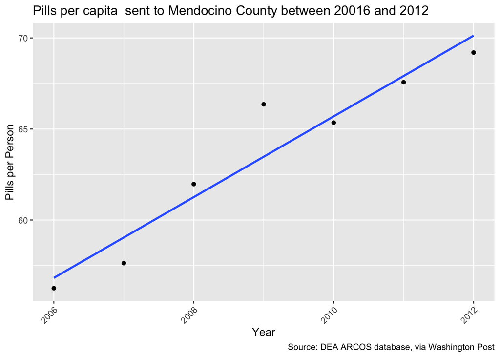

```r
ggplot(mendocino_finished) +
 geom_point(aes(year, pills_per_capita)) +
 labs(x="Year", y="Pills per Person", title="Pills per capita  sent to Mendocino County between 20016 and 2012", caption = "Source: DEA ARCOS database, via Washington Post", fill="year") +
 theme(axis.text.x = element_text(angle = 45, hjust = 1)) +
 geom_smooth(aes(year, pills_per_capita), method = "lm", se = FALSE)
```

```r
 #geom_text(aes(year, pills_per_capita, label=buyer_county))
```

Question 14: What does the graph of pills per capita per year look like for Wayne?

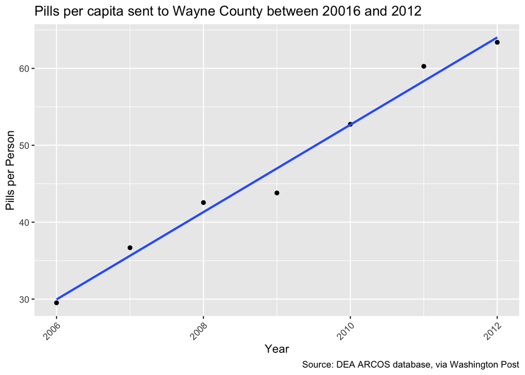

```r
ggplot(wayne_finished) +
 geom_point(aes(year, pills_per_capita)) +
 labs(x="Year", y="Pills per Person", title="Pills per capita sent to Wayne County between 20016 and 2012", caption = "Source: DEA ARCOS database, via Washington Post", fill="year") +
 theme(axis.text.x = element_text(angle = 45, hjust = 1)) +
 geom_smooth(aes(year, pills_per_capita), method = "lm", se = FALSE)
```

```r
 #geom_text(aes(year, pills_per_capita, label=buyer_county))
```

Question 15: What does the graph of pills per capita per year look like for Tuscaloosa?

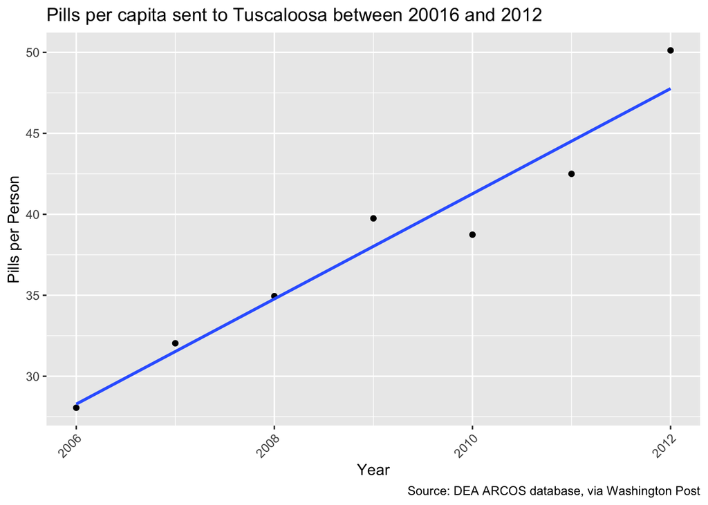

```r
ggplot(tusca_finished) +
 geom_point(aes(year, pills_per_capita)) +
 labs(x="Year", y="Pills per Person", title="Pills per capita sent to Tuscaloosa between 20016 and 2012", caption = "Source: DEA ARCOS database, via Washington Post", fill="year") +
 theme(axis.text.x = element_text(angle = 45, hjust = 1)) +
 geom_smooth(aes(year, pills_per_capita), method = "lm", se = FALSE)
```

```r
 #geom_text(aes(year, pills_per_capita, label=buyer_county))
```

Question 16: What does the graph of pills per capita per year look like for Imperial?

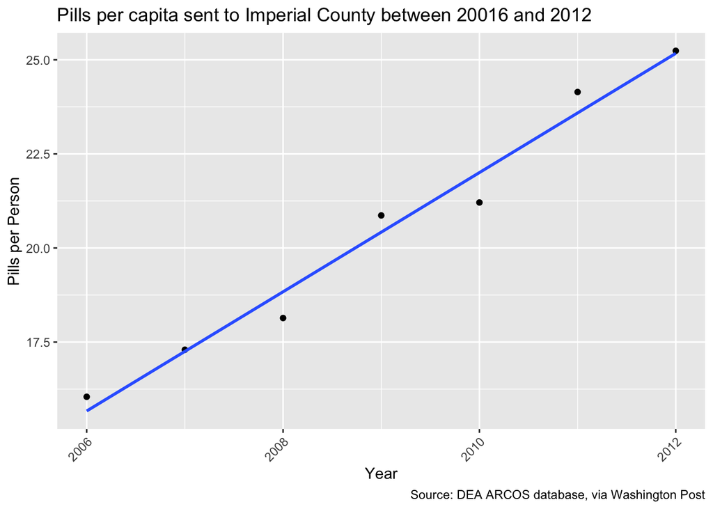

```r
ggplot(imp_finished) +
 geom_point(aes(year, pills_per_capita)) +
 labs(x="Year", y="Pills per Person", title="Pills per capita sent to Imperial County between 20016 and 2012", caption = "Source: DEA ARCOS database, via Washington Post", fill="year") +
 theme(axis.text.x = element_text(angle = 45, hjust = 1)) +
 geom_smooth(aes(year, pills_per_capita), method = "lm", se = FALSE)
```

```r
 #geom_text(aes(year, pills_per_capita, label=buyer_county))
```